[figure not shown]

# TP3 : Manipuler les branches.

**Objectifs :**

- Créer une branche
- Merger une branche
- Supprimer une branche.
- Savoir résoudre un conflit avec un mergetool ou à la main

--

- Commencer le TP depuis le tag tp3-start :

```bash
$ git checkout -b tp3 tp3-start
Switched to a new branch 'tp3'
```

## 1. Manipuler les branches.

- Créer une branche `link` au niveau de la branche `tp3` :

```bash
$ git branch link
```

- Lister les branches locales :

```bash
$ git branch
master
* tp3
link
```

- Changer la branche en cours pour `link` et vérifier

```bash
$ git checkout link
Switched to branch 'link'

$ git branch
* link
master
tp3
```

- Créer une nouvelle branche `branche-test` pour y travailler. Puis supprimer là.

```bash
$ git checkout -b branche-test
Switched to a new branch 'branche-test'

$ git status
On branch branche-test
nothing to commit, working directory clean

$ git branch -d branche-test
error: Cannot delete the branch 'branche-test' which you are currently on.

$ git checkout link
Switched to branch 'link'

$ git branch -d branch-test
Deleted branch branche-test (was 1a4c660).
```

## 2. Ajouter la fonctionnalité "lien".

Nous souhaitons ajouter la possibilité d'avoir des liens dans notre parser.

Ajouter dans `converter/tests/features` deux fichiers :

- `link.md`
- `link.html`

Dans le premier ajouter :

```bash
[Elephorm](http://elephorm.com)
```

Et dans le second :

```bash
<a href="http://elephorm.com">Elephorm</a>
```

Ajouter dans le parser les lignes suivantes dans le fichier `markdown.js`:

```bash
+ var parseLink = function(str) {
+  var linkRegExp = /\[([^\[]+)\]\(([^\)]+)\)/;
+  var stra = [];
+  while ((stra = linkRegExp.exec(str)) !== null) {
+    str = str.replace(stra[0], '<a ' + 'href="' + stra[2] + '">' + stra[1] + '</a>');
+  }
+  return str;
+ }
+
+
 var markdown = {
   parse: function (str, strict) {
     'use strict';
     str = parseHeadline(str);
     str = parseHorizontaleLine(str);
+    str = parseLink(str);
     return str;
   }
 };
```

- Vérifier que les tests passent :

```bash
$ npm run test
parse() features testsuite
    ✓ h1
    ✓ horizontal_line
    ✓ link
```

- Faire un commit, avec interface graphique ou pas :

```bash
$ git status

$ git add converter/

$ git status

$ git commit -m "add link in parser"
[link c3af8ef] add link in parser
 3 files changed, 13 insertions(+)
 create mode 100644 converter/tests/features/link.html
 create mode 100644 converter/tests/features/link.md
```

## 3. Ajouter la fonctionnalité mettre en gras dans la branche principale.

- Placer vous sur la branche `tp3`

```bash
$ git checkout tp3

$ git branch
* tp3
link
```

- Ajouter dans `converter/tests/features` deux fichiers :
  - `bold.md`
  - `bold.html`

Dans le premier ajouter :

```bash
** en gras **
```

- Et dans le second :

```bash
<strong> en gras </strong>
```

- Ajouter dans le parser les lignes suivantes dans le fichier `markdown.js`. La fonction parseBold doit être ajoutée en début du fichier.

```bash
+ var parseBold = function(str) {
+  var boldRegExp = /(\*\*)(.*?)\1/;
+  var stra = [];
+  while ((stra = boldRegExp.exec(str)) !== null) {
+    str = str.replace(stra[0], '<strong>' + stra[2] + '</strong>')
+  }
+  return str;
+ }
+

 var markdown = {
   parse: function (str, strict) {
@@ -33,6 +42,7 @@ var markdown = {
     str = parseHeadline(str);
     +    str = parseBold(str);
     str = parseHorizontaleLine(str);
     return str;
   }
 };
```

- Vérfier que les tests passent :

```bash
   parse() features testsuite
    ✓ bold
    ✓ h1
    ✓ horizontal_line

  3 passing (10ms)
```

- Faites un nouveau commit

```bash
$ git status

$ git add converter/

$ git status

$ git commit -m "add bold in parser"
[tp3 418e381] add bold in parser
 3 files changed, 29 insertions(+)
 create mode 100644 converter/tests/features/bold.html
 create mode 100644 converter/tests/features/bold.md
```

  ```bash
  $ git log --pretty=oneline --abbrev-commit --graph --decorate --all
  * 418e381 (HEAD, tp3) add bold in parser
  | * c3af8ef (link) add link in parser
  |/
  * 1a4c660 (tag: tp3-start, master) add horizontal line to parser
  * 5d78b73 (tag: tp2-start, origin/master, origin/HEAD) Initial commit with  add headlines parser
  ```

  - Soit avec gitk :

  ```
  $ gitk --all
  ```

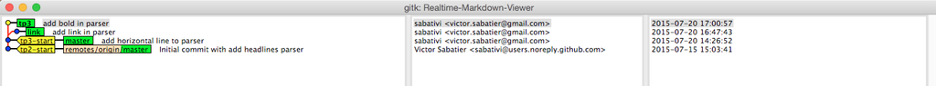